# Pixel-CMDs

Ben Cook

Conroy Group Meeting

21 March 2018

# Background

Observing a galaxy (photometry, spectra maybe, etc.)

Our goal is generically to measure its:

- Stellar Mass
- Metal Abundances
- Star Formation History
- Dust Content
- ...

A galaxy's light is (primarily) contributed by the stars it contains.

So, we combine our knowledge of stars and their evolution into understanding galaxies.

**Stellar Population Synthesis**

## Integrated Stellar Populations

or: SED Modelling

[figure not shown]

**Leja et al. 2018**

## Integrated Stellar Populations

- Can assume fully-populated isochrones
- Typically need wide spectral coverage
- Uncertanties come from rare, highly-evolved phases of stellar evolution (+AGN, dust, ...)

## Resolved Stellar Populations

or: CMD modelling **M13 (as seen by HST)**

[figure not shown]

## Resolved Stellar Populations

[figure not shown]

## Resolved Stellar Populations

- Observe individual stars, and compare to isochrone models
- Often only need 2 colors to measure metallicity, SFH
- Limited by spatial resolution (crowding) and exposure (faintness limit)

## Semi-Resolved Stellar Populations

or: Pixel-CMDs

We're studying the intermediate regime, where:

- Can't resolve individual stars (crowding limited)
- Can't assume isochrones are fully populated (surface-brightness fluctuations)

It makes sense to describe systems by $N_{pix}$: the typical number of stars per pixel

- Resolved CMDs: $N_{pix} \ll 1$
- Semi-Resolved Stellar Populations: $N_{pix} \sim 1 \rightarrow 10^{7}$
- Integrated Stellar Populations: $N_{pix} \gg 10^7$

Due to Poisson fluctuations, some pixels will have fewer bright-rare stars than others.

- Surface-brightness fluctuations contain information!

**M31 Bulge (PHAT survey)**

[figure not shown]

What is the distribution of colors and magnitudes on a pixel-by-pixel basis?

**Pixel Color-Magnitude Diagrams**

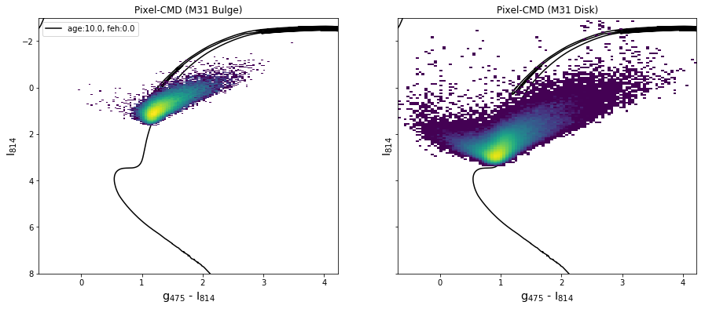

```python
fig, axes = plt.subplots(ncols=2, figsize=(15, 6), sharex=True, sharey=True)
_ = plot_pcmd(pcmd_m31_b, title='Pixel-CMD (M31 Bulge)', norm=norm, ax=axes[0], isochrone_kwargs={'system':'ab'})
_ = plot_pcmd(pcmd_m31_d, title='Pixel-CMD (M31 Disk)', norm=norm, ax=axes[1], isochrone_kwargs={'system':'ab'})
axes[0].set_ylim([8, -3.])
axes[0].legend(loc=0)
```

# The Basic Model

For a given population of stars (metallicity, Star-formation History, IMF),

want to create a forward-model of the image and pixel-CMD

- use isochrones (magnitude, color, mass) from MIST
- assume each pixel in the image contains roughly $N_{pix}$ stars
- randomly populate the pixels with stars from the isochrones
- apply observational effects (dust extinction, HST PSF, ...)
- compare resulting pixel-CMD to observed data

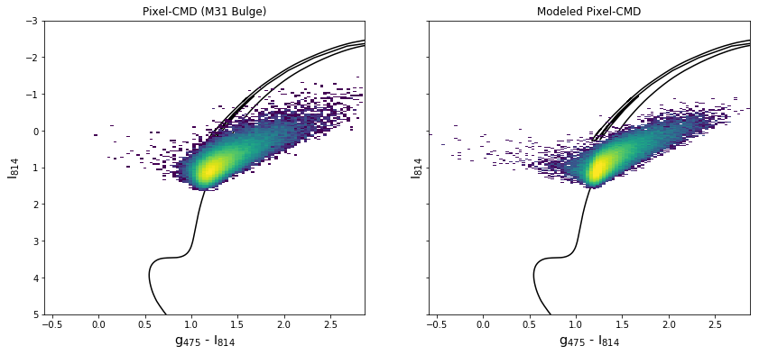

```python
fig, axes = plt.subplots(ncols=2, figsize=(14, 6), sharey=True, sharex=True)
plot_pcmd(pcmd_m31_b, title='Pixel-CMD (M31 Bulge)', ax=axes[0], isochrone_kwargs={'system':'ab'})
plot_pcmd(pcmd_model_b, title='Modeled Pixel-CMD', ax=axes[1], isochrone_kwargs={'system':'ab'})
axes[0].set_ylim([5., -3.]);
```

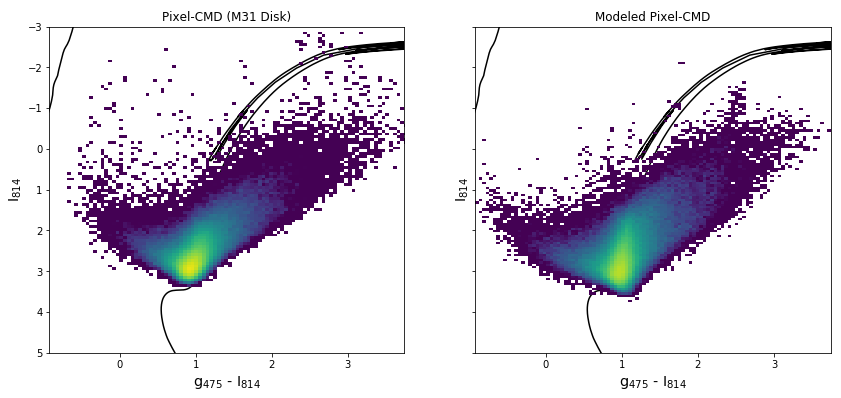

```python
fig, axes = plt.subplots(ncols=2, figsize=(14, 6), sharey=True, sharex=True)
plot_pcmd(pcmd_m31_d, title='Pixel-CMD (M31 Disk)', ax=axes[0], isochrone_kwargs={'system':'ab'})
plot_pcmd(pcmd_model_d, title='Modeled Pixel-CMD', ax=axes[1], isochrone_kwargs={'system':'ab'})
axes[0].set_ylim([5., -3.]);
```

# Model parameters

## Npix: integrated stellar mass

```
((5.0, -5.0), (0.5, 3), None)
```

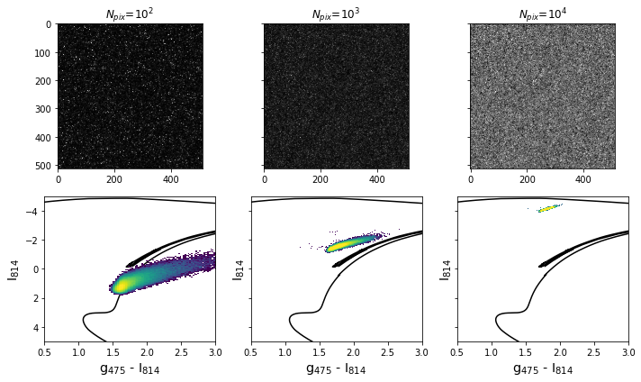

```python
fig, a = plt.subplots(ncols=3, nrows=2, figsize=(10, 6), sharex='row', sharey='row')
a[0,0].imshow(im1_n[0],cmap='Greys_r'),a[0,0].set_title(r'$N_{pix}$=10$^2$')
a[0,1].imshow(im2_n[0],cmap='Greys_r'),a[0,1].set_title(r'$N_{pix}$=10$^3$')
a[0,2].imshow(im3_n[0],cmap='Greys_r'),a[0,2].set_title(r'$N_{pix}$=10$^4$')
plot_pcmd(pcmd1_n,ax=a[1,0]), plot_pcmd(pcmd2_n,ax=a[1,1]), plot_pcmd(pcmd3_n,ax=a[1,2])
a[1,0].set_ylim([5., -5.]),a[1,0].set_xlim([0.5, 3]),plt.tight_layout()
```

## [Fe/H]: Metal Abundance

- Shifts pCMD towards red
- Also alters shape of pCMD distribution

```
((5.0, -10.0), (0.5, 3), None)
```

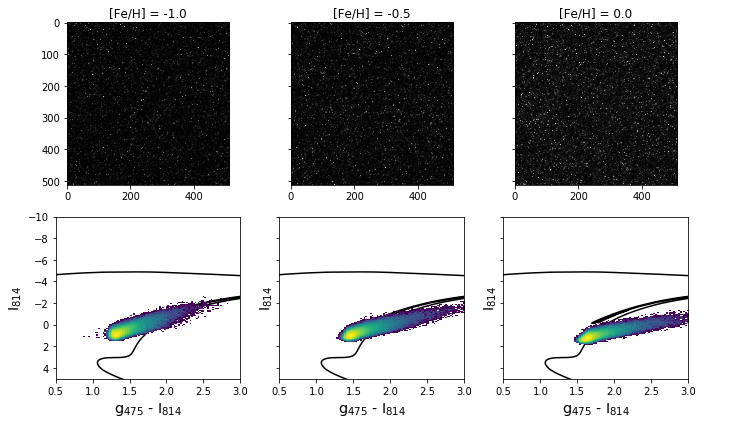

```python
fig, a = plt.subplots(ncols=3, nrows=2, figsize=(10, 6), sharex='row', sharey='row')
a[0,0].imshow(im1_f[0],cmap='Greys_r'),a[0,0].set_title(r'[Fe/H] = -1.0')
a[0,1].imshow(im2_f[0],cmap='Greys_r'),a[0,1].set_title(r'[Fe/H] = -0.5')
a[0,2].imshow(im3_f[0],cmap='Greys_r'),a[0,2].set_title(r'[Fe/H] = 0.0')
plot_pcmd(pcmd1_f,ax=a[1,0]),plot_pcmd(pcmd2_f,ax=a[1,1]),plot_pcmd(pcmd3_f,ax=a[1,2])
a[1,0].set_ylim([5., -10.]),a[1,0].set_xlim([0.5, 3]),plt.tight_layout()
```

## E(B-V): Dust Extinction

- Shifts pCMD towards red

```
((5.0, -10.0), (0.5, 5), None)
```

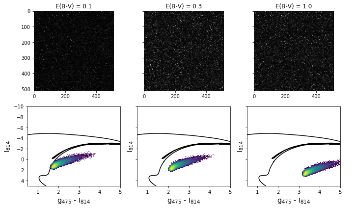

```python
fig, a = plt.subplots(ncols=3, nrows=2, figsize=(10, 6), sharex='row', sharey='row')
a[0,0].imshow(im1_d[0], cmap='Greys_r'),a[0,0].set_title(r'E(B-V) = 0.1')
a[0,1].imshow(im2_d[0], cmap='Greys_r'),a[0,1].set_title(r'E(B-V) = 0.3')
a[0,2].imshow(im3_d[0], cmap='Greys_r'),a[0,2].set_title(r'E(B-V) = 1.0')
plot_pcmd(pcmd1_d, ax=a[1,0]), plot_pcmd(pcmd2_d, ax=a[1,1]), plot_pcmd(pcmd3_d, ax=a[1,2])
a[1,0].set_ylim([5., -10.]),a[1,0].set_xlim([0.5, 5]),plt.tight_layout()
```

## Star-Formation History

- Simplest model: SSP
  - $N_{pix}$ and age
- $\tau$ model: $SFR \sim \exp(-t / \tau)$
  - $N_{pix}$ and $\tau$
- Non-Parametric model:
  - Fit for $N_{pix}$ in each age bin

```
((3.0, -2.0), (0.5, 3), None)
```

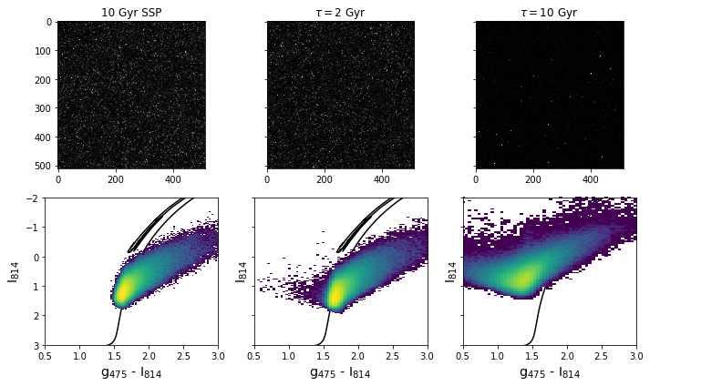

```python
fig, a = plt.subplots(ncols=3, nrows=2, figsize=(10, 6), sharex='row', sharey='row')
a[0,0].imshow(im1_s[0],cmap='Greys_r'),a[0,0].set_title(r'10 Gyr SSP')
a[0,1].imshow(im2_s[0],cmap='Greys_r'),a[0,1].set_title(r'$\tau = 2$ Gyr')
a[0,2].imshow(im3_s[0],cmap='Greys_r'),a[0,2].set_title(r'$\tau = 10$ Gyr')
plot_pcmd(pcmd1_s, ax=a[1,0]),plot_pcmd(pcmd2_s,ax=a[1,1]),plot_pcmd(pcmd3_s,ax=a[1,2])
a[1,0].set_ylim([3., -2.]),a[1,0].set_xlim([0.5, 3]), plt.tight_layout()
```

# Fit Using Nested Sampling (Dynesty)

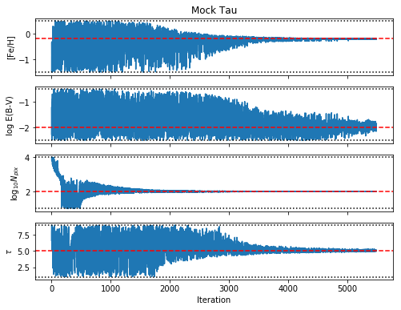

```python
res['base'].plot_chains(chains_only=True);
```

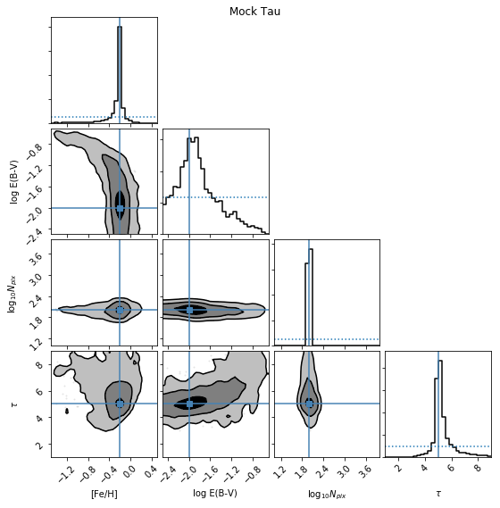

```python
f, a = plt.subplots(ncols=4, nrows=4, figsize=(8,8)); res['base'].plot_corner(f, burn=2000, weight=False);
```

# Complex Models

## Metallicity Distribution

- What if the underlying population has a Gaussian MDF?
- What sorts of bias is introduced by assuming a single [Fe/H]?

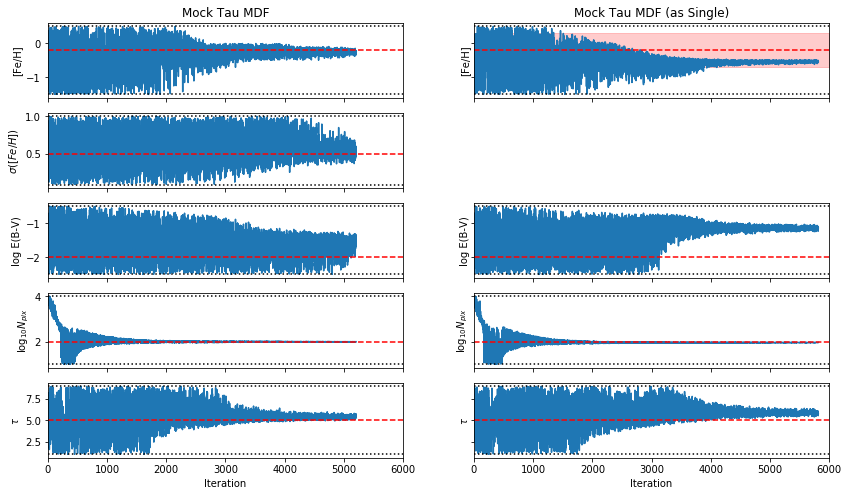

```python
fig, axes = plt.subplots(ncols=2, nrows=5, figsize=(14, 8), sharex=True, sharey='row')
_ = res['single'].plot_chains(axes[[0,2,3,4],1], chains_only=True)
_ = res['mdf'].plot_chains(axes[:,0], chains_only=True);axes[1,1].axis('off'); axes[0,0].set_xlim([0, 6000])
xl = axes[0,1].get_xlim(); axes[0,1].fill_between(x=xl, y1=[-0.7, -0.7], y2=[0.3, 0.3], color='r', alpha=0.2, zorder=-1)
```

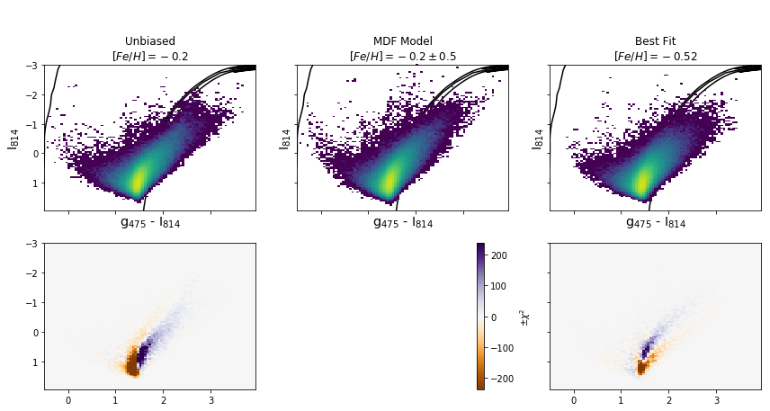

```python
fig, axes = plt.subplots(ncols=3, nrows=2, figsize=(12, 6), sharex=True, sharey=True)
for pcmd, ax, t in zip([pcmd1, pcmd2, pcmd3], axes[0], titles): plot_pcmd(pcmd, ax=ax, bins=b, title=t)
axes[1,1].axis('off'); plt.subplot(axes[1,0]); plt.imshow(im1, **kwargs); axes[1,2].imshow(im2, **kwargs)
plt.colorbar(ax=axes[1,1], label=r'$\pm \chi^2$'); axes[0,0].set_ylim(ymax=-3); plt.tight_layout()
```

## Other Models

- Lognormal Dust
  - Model distribution of dust between sightlines
- Non-fixed $N_{pix}$
  - What if stellar density changes significantly across image?

# GPU Acceleration

```python
%%time
results = driv_cpu.simulate(ssp, 128) # 128x128 image w/ CPU
```

```
CPU times: user 2.66 s, sys: 391 ms, total: 3.05 s
Wall time: 3.05 s
```

```python
%%time
results = driv_gpu.simulate(ssp, 128) # 128x128 image w/ GPU acceleration
```

```
CPU times: user 121 ms, sys: 28 ms, total: 149 ms
Wall time: 238 ms
```

```python
%%time
results = driv_cpu.simulate(ssp, 256) # 256x256 image w/ CPU
```

```
CPU times: user 10.4 s, sys: 1.57 s, total: 12 s
Wall time: 12 s
```

```python
%%time
results = driv_gpu.simulate(ssp, 256) # 256x256 image w/ GPU acceleration
```

```
CPU times: user 179 ms, sys: 35 ms, total: 214 ms
Wall time: 301 ms
```

```
(-3.5701109528541566, 30)
```

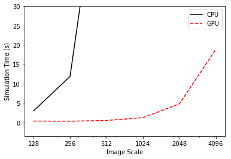

```python
fig, ax = plt.subplots()
ax.plot(N_ims[:len(t_cpu)], t_cpu, 'k-', label='CPU'); ax.plot(N_ims, t_gpu, 'r--', label='GPU')
ax.set_xlabel('Image Scale'); ax.set_ylabel('Simulation Time (s)'); ax.set_xscale('log'); #; ax.set_yscale('log');
ax.set_xticks(N_ims); ax.set_xticklabels(N_ims); ax.legend(loc=0); ax.set_title(''); ax.set_ylim(ymax=30)
```

## Where to get all these GPUs?

- Odyssey is pretty full up

[figure not shown]

## Move to the cloud!

[figure not shown]

# Next Steps

- Complete mock testing
  - What complexities need to be modeled?
  - Which can be ignored
- Apply method to M51
  - Goal: recover spatially-resolved SFH across the face of the galaxy

[figure not shown]